# R Download Guide

JP

8/14/2021

# Guide to Downloading R

[Download Link Here](https://ftp.osuosl.org/pub/cran/)

## Why am I recommending you use R for this course?

1. Because R is just a huge calculator.

```r
3 + 5
```

```
## [1] 8
```

```r
tictoc::tic()
423164572464815794858642 + 423164572464815794858642
```

```
## [1] 846329144929631646804264
```

```r
tictoc::toc()
```

```
## 0 sec elapsed
```

```r
423164572464815794858642*2
```

```
## [1] 846329144929631646804264
```

2. It’s free.
3. It also lets you save parts in what are called `objects`.
4. You can turn in scripts instead of doing everything by hand. Which saves you writing everything by hand and having to take pictures of your work. It saves me having to figure out all of your handwriting.

## Step-by-step of downloading R (Windows)

1. Download R for Windows or Mac

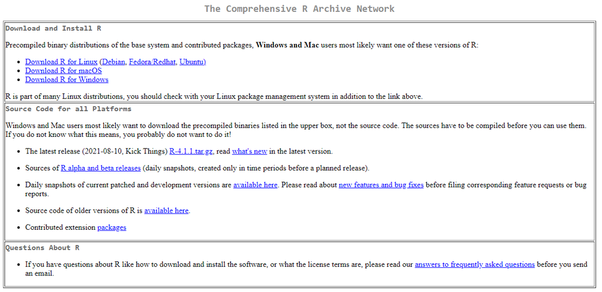

Download R page

2. Download Base R

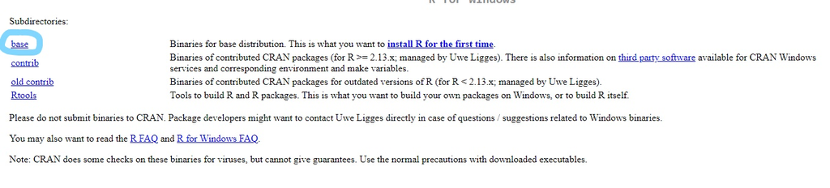

Download Base

3. Final Download Page

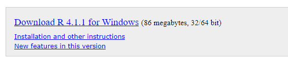

Final Download Page

4. Main R Page

[figure not shown]

Main R Page

You can work in this page, however you won’t be able to see the work you’ve done. For that, you’ll want to create a script.

5. Creating a script

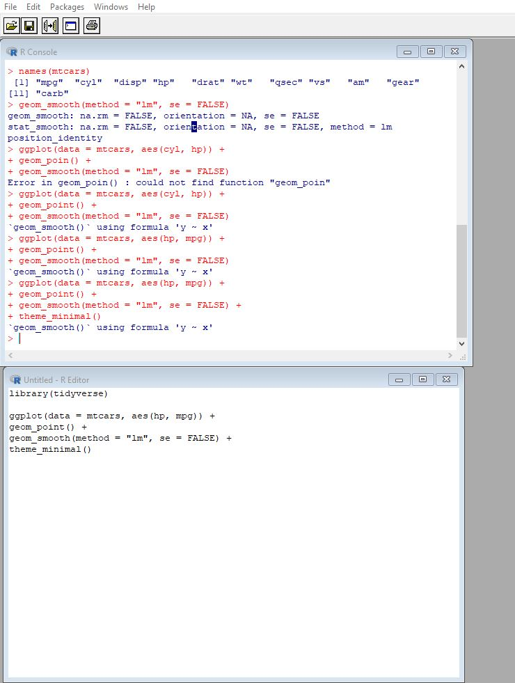

File –> New Script

File –> Save As

Save with the name `Problem Set #_Pedroza Jonathan` for each assignment followed by your name.

You can save the script too. This will be what is turned in for problem set assignments. From the screenshot, you can see that the top is the console that shows everything that is run. Below is the script where you can save your work. To run something you must highlight the whole selection and use `ctrl + R` for Windows or `Command + R` for Mac.

6. Highlighting Code to Run

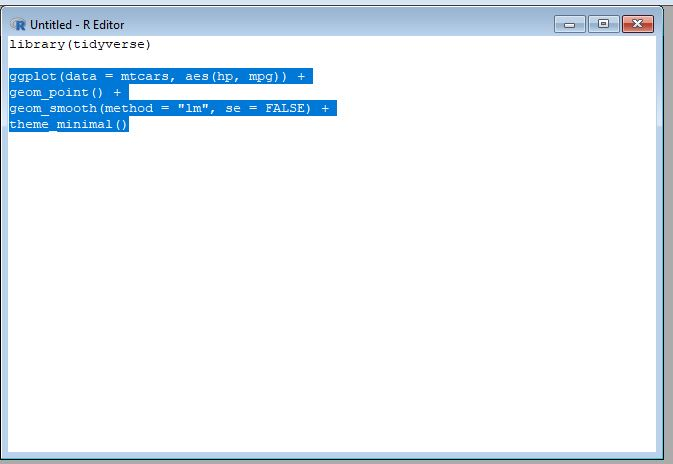

Highlighting Code

### Mac Instructions

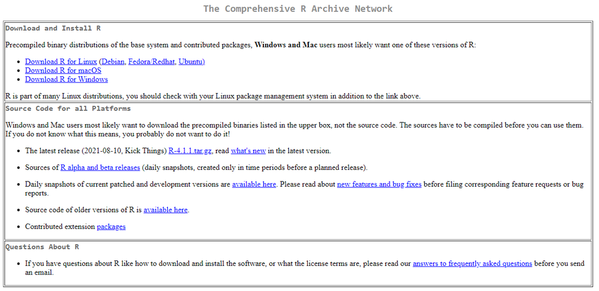

1. Download R page

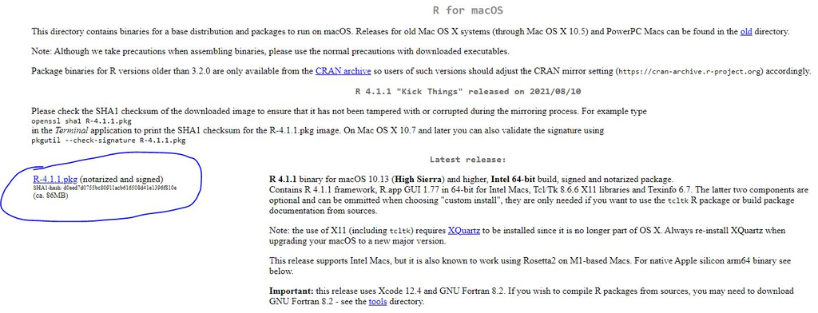

2. Download R-4.1.1pkg

3. Follow Instructions by clicking Next.

## Objects

You can either use arrows or equal signs to create objects. The objects will allow you to save every single part of the functions you will be writing. For example, below I will show you the steps taken to get the standard deviation of some simulated test scores. But to get the standard deviation, you’ll first have to do some steps that are shown in your textbook.

First, I’m going to create some fake data so we can move forward. Below is to show that using `=` or `<-` gets you the same 100 answers.

**Unnecessary Information:** the `rnorm` functions is just stating that I want 100 observations with an average test score of 87.5 and I want the scores to vary around 87.5 by a standard deviation of 1.87. We’ll get back to this later this semester. Additionally, the `set.seed()` is simply like a save point to make sure I always get the same 100 values for the observations.

```r
set.seed(08152021)
test_scores = rnorm(100, mean = 87.5, sd = 1.87)

set.seed(08152021)
test_scores2 <- rnorm(100, mean = 87.5, sd = 1.87)

test_scores
```

```
##   [1] 85.45540 85.03891 86.60484 84.80380 84.94609 88.25278 87.85473 89.01268
##   [9] 87.05635 87.24757 88.43037 89.18264 90.62361 87.01734 87.03589 88.37339
##  [17] 87.42268 84.91813 87.04836 87.36818 84.41874 87.61071 85.04141 82.43297
##  [25] 85.83362 86.12144 86.65049 87.90397 88.60613 88.35940 88.24747 88.14985
##  [33] 86.76274 90.66848 87.39724 84.18169 87.18233 88.10315 86.29297 86.73223
##  [41] 86.30923 86.82375 88.27537 85.65536 88.68052 85.35382 86.39760 88.46208
##  [49] 84.62922 87.05043 86.72550 85.34031 91.89878 85.76954 91.42014 88.90195
##  [57] 90.74495 84.96993 85.87479 86.73167 87.21493 86.53028 86.64107 89.50916
##  [65] 89.73331 88.49214 85.93042 89.23942 85.96202 88.71100 90.85411 86.06414
##  [73] 88.59206 88.22118 85.86870 86.51234 87.00846 89.47011 89.59172 88.28199
##  [81] 86.55766 88.57370 86.89643 86.74550 88.59607 88.13604 85.99384 84.03132
##  [89] 86.90641 81.85202 84.50241 85.57414 87.71799 88.75001 87.95303 85.92996
##  [97] 88.47104 85.31110 85.07190 87.02999
```

```r
test_scores2
```

```
##   [1] 85.45540 85.03891 86.60484 84.80380 84.94609 88.25278 87.85473 89.01268
##   [9] 87.05635 87.24757 88.43037 89.18264 90.62361 87.01734 87.03589 88.37339
##  [17] 87.42268 84.91813 87.04836 87.36818 84.41874 87.61071 85.04141 82.43297
##  [25] 85.83362 86.12144 86.65049 87.90397 88.60613 88.35940 88.24747 88.14985
##  [33] 86.76274 90.66848 87.39724 84.18169 87.18233 88.10315 86.29297 86.73223
##  [41] 86.30923 86.82375 88.27537 85.65536 88.68052 85.35382 86.39760 88.46208
##  [49] 84.62922 87.05043 86.72550 85.34031 91.89878 85.76954 91.42014 88.90195
##  [57] 90.74495 84.96993 85.87479 86.73167 87.21493 86.53028 86.64107 89.50916
##  [65] 89.73331 88.49214 85.93042 89.23942 85.96202 88.71100 90.85411 86.06414
##  [73] 88.59206 88.22118 85.86870 86.51234 87.00846 89.47011 89.59172 88.28199
##  [81] 86.55766 88.57370 86.89643 86.74550 88.59607 88.13604 85.99384 84.03132
##  [89] 86.90641 81.85202 84.50241 85.57414 87.71799 88.75001 87.95303 85.92996
##  [97] 88.47104 85.31110 85.07190 87.02999
```

Okay, now that I have test scores, let’s see what the sum of those scores are. I will also create an additional object that holds all the observed test scores.

```r
sum_score = sum(test_scores)
sum_score
```

```
## [1] 8715.435
```

```r
n = 100
n
```

```
## [1] 100
```

Let’s see what the average test score was. First, we can see what the average score is, but let’s also save the average/mean test score for further analyses.

```r
sum_score/n
```

```
## [1] 87.15435
```

```r
xbar = sum_score/n
xbar
```

```
## [1] 87.15435
```

Now that we have the average test scores, let’s see how far students were away from that average score. This is the `deviance` from the average test score. We’ll come back to this for class.

```r
dev = test_scores - xbar
dev
```

```
##   [1] -1.69895063 -2.11543377 -0.54950964 -2.35054918 -2.20826117  1.09842744
##   [7]  0.70038247  1.85832899 -0.09800264  0.09321859  1.27602060  2.02828882
##  [13]  3.46926529 -0.13701288 -0.11845854  1.21904306  0.26833612 -2.23621715
##  [19] -0.10598822  0.21382763 -2.73561039  0.45636250 -2.11294183 -4.72138124
##  [25] -1.32072879 -1.03291279 -0.50385512  0.74962436  1.45178571  1.20505656
##  [31]  1.09312047  0.99550464 -0.39160364  3.51412860  0.24289364 -2.97265340
##  [37]  0.02798038  0.94879757 -0.86137807 -0.42211991 -0.84511901 -0.33059819
##  [43]  1.12102660 -1.49898420  1.52617517 -1.80052515 -0.75674832  1.30773124
##  [49] -2.52512808 -0.10392202 -0.42885017 -1.81404019  4.74442757 -1.38480849
##  [55]  4.26579627  1.74760027  3.59060616 -2.18441701 -1.27955529 -0.42267812
##  [61]  0.06058492 -0.62406522 -0.51327725  2.35480726  2.57896545  1.33779102
##  [67] -1.22392977  2.08507166 -1.19232878  1.55665387  3.69976301 -1.09021016
##  [73]  1.43771046  1.06682951 -1.28565090 -0.64201284 -0.14588750  2.31575780
##  [79]  2.43737119  1.12763908 -0.59668351  1.41935465 -0.25791805 -0.40884673
##  [85]  1.44172456  0.98168885 -1.16050797 -3.12303324 -0.24793633 -5.30232892
##  [91] -2.65193375 -1.58020804  0.56364341  1.59565950  0.79868137 -1.22439192
##  [97]  1.31668741 -1.84324537 -2.08244793 -0.12435428
```

Totaling the deviance shows that no matter what, all students’ scores should zero-out. I’ll show this visually shortly.

```r
total_dev = sum(dev)
total_dev
```

```
## [1] 0.0000000000004547474
```

We’ll also see when scores are “standardized” by squaring the test scores. This will be important for analyses later in this class.

```r
dev_sq = (test_scores - xbar)^2
dev_sq
```

```
##   [1]  2.8864332563  4.4750600481  0.3019608395  5.5250814565  4.8764173759
##   [6]  1.2065428454  0.4905356110  3.4533866256  0.0096045170  0.0086897057
##  [11]  1.6282285724  4.1139555396 12.0358016270  0.0187725299  0.0140324253
##  [16]  1.4860659762  0.0720042736  5.0006671244  0.0112335018  0.0457222548
##  [21]  7.4835642184  0.2082667330  4.4645231665 22.2914408118  1.7443245408
##  [26]  1.0669088302  0.2538699852  0.5619366773  2.1076817494  1.4521613228
##  [31]  1.1949123518  0.9910294906  0.1533534099 12.3490997921  0.0589973212
##  [36]  8.8366682326  0.0007829014  0.9002168246  0.7419721733  0.1781852176
##  [41]  0.7142261393  0.1092951606  1.2567006366  2.2469536284  2.3292106482
##  [46]  3.2418908193  0.5726680161  1.7101609989  6.3762718118  0.0107997853
##  [51]  0.1839124672  3.2907418122 22.5095930027  1.9176945449 18.1970178309
##  [56]  3.0541066965 12.8924526081  4.7716776620  1.6372617420  0.1786567934
##  [61]  0.0036705323  0.3894573947  0.2634535353  5.5451172200  6.6510627683
##  [66]  1.7896848067  1.4980040814  4.3475238358  1.4216479133  2.4231712719
##  [71] 13.6882463060  1.1885582035  2.0670113807  1.1381251936  1.6528982296
##  [76]  0.4121804835  0.0212831620  5.3627341810  5.9407783268  1.2715699037
##  [81]  0.3560312097  2.0145676109  0.0665217215  0.1671556520  2.0785697164
##  [86]  0.9637129888  1.3467787541  9.7533366465  0.0614724255 28.1146920272
##  [91]  7.0327526059  2.4970574634  0.3176938880  2.5461292383  0.6378919305
##  [96]  1.4991355782  1.7336657389  3.3975534906  4.3365893818  0.0154639860
```

Let’s also collect an object of the total deviance squared.

```r
total_dev_sq = sum(dev_sq)
total_dev_sq
```

```
## [1] 327.9143
```

Similar to the mean, we need to get the total observations. We will talk about why we subtract 1 later in this class.

```r
sample_obs = n - 1
sample_obs
```

```
## [1] 99
```

To see how much the scores collectively vary from the average test score, we will get the variance.

```r
variance = total_dev_sq/sample_obs
variance
```

```
## [1] 3.312266
```

To get the standard deviation, we conduct the square root of the variance.

```r
standard_dev = sqrt(variance)
standard_dev
```

```
## [1] 1.819963
```

Thanks to `R`, we can use the built-in functions to see both the mean and standard deviations of our simulated test scores.

```r
mean(test_scores)
```

```
## [1] 87.15435
```

```r
sd(test_scores)
```

```
## [1] 1.819963
```

To get a little fancier, we can create a database/dataset/dataframe/tibble to visualize the deviance and squared deviance.

```r
library(tidyverse)
```

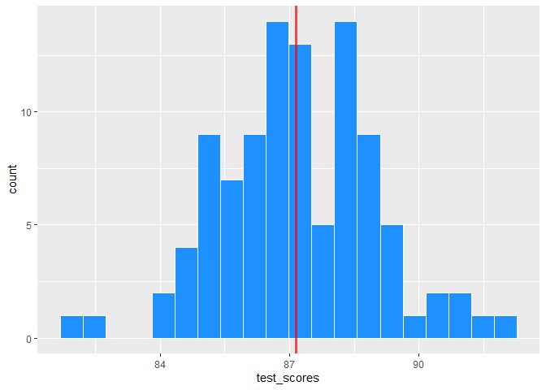

```r
dataset <- tibble::tibble(scores = test_scores,
                          xbar_mean = xbar,
                          dev = dev,
                          dev_sq = dev_sq) %>%
  rowid_to_column()

ggplot(data = dataset, aes(test_scores)) +
  geom_histogram(color = "white", fill = "dodgerblue", bins = 20) +
  geom_vline(xintercept = 87.15, color = "red", size = 1.25, alpha = .7)
```

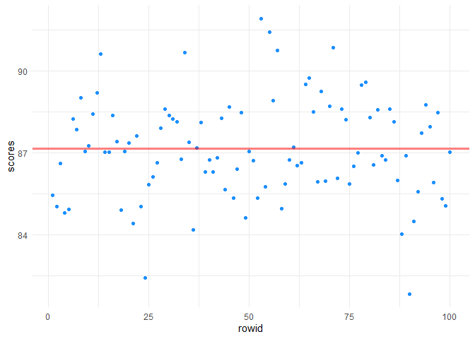

```r
ggplot(data = dataset, aes(rowid, scores)) +
  geom_point(color = "dodgerblue") +
  geom_hline(yintercept = 87.15, color = "red", size = 1.25, alpha = .5) +
  theme_minimal()
```

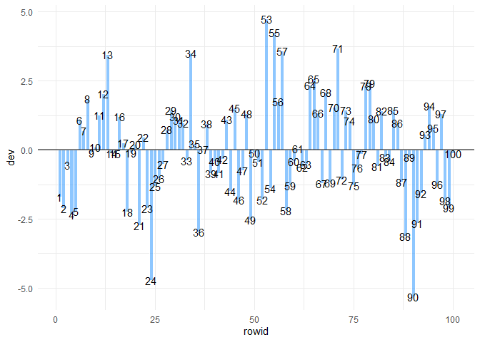

```r
ggplot(data = dataset, aes(rowid, dev)) +
  geom_col(position = "dodge2", fill = "dodgerblue", color = "white", alpha = .5) +
  geom_text(label = dataset$rowid) +
  geom_hline(yintercept = 0, color = "black", size = 1, alpha = .5) +
  theme_minimal()
```

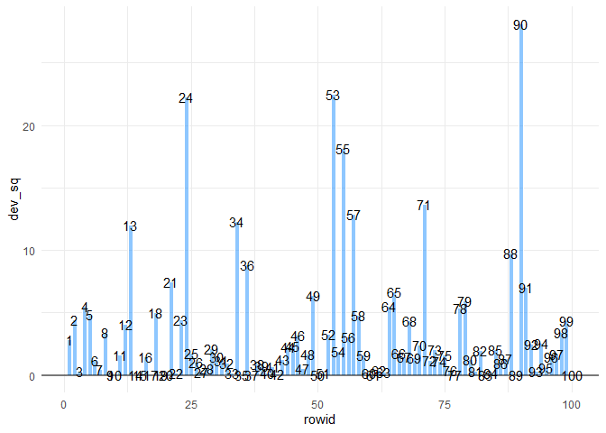

```r
ggplot(data = dataset, aes(rowid, dev_sq)) +
  geom_col(position = "dodge2", fill = "dodgerblue", color = "white", alpha = .5) +
  geom_text(label = dataset$rowid) +
  geom_hline(yintercept = 0, color = "black", size = 1, alpha = .5) +
  theme_minimal()
```

We can now get some more information from this. From all of these graphs, students #90, and #24 appear to need some additional help here. We can also see that both students #53 and #55 may be able to help those students as they scored higher than all the other students.

# Additional Guide to Downloading RStudio

## Why Use RStudio?

### **You don’t need Rstudio, especially for use in this class.**

1. It is more user-friendly than R. It is an easier transition from SPSS.
2. It looks better.
3. Has keyboard shortcuts.
4. You can do your analyses, write your paper, and see your visuals at the same time.
5. It’s also free.
6. You can create so much with it.
- [Websites](https://jonathan-a-pedroza.netlify.app/)
- [Data visualization dashboards](https://jpedroza1228.github.io/gradschool_dashboard/)
- [Create external servers for visualizations or analyses that take forever](https://shiny.rstudio.com/gallery/)

[Here is the download link](https://www.rstudio.com/products/rstudio/download/)